# Lecture 18 - Data Modeling

2022-12-01

## Modeling Intro

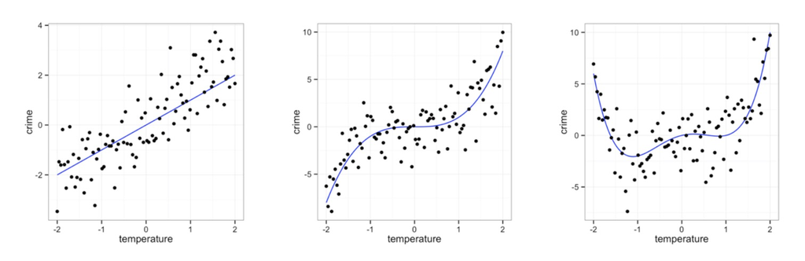

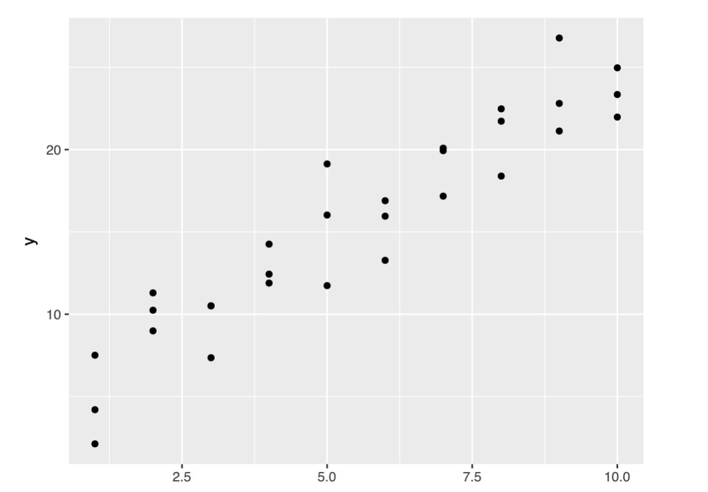

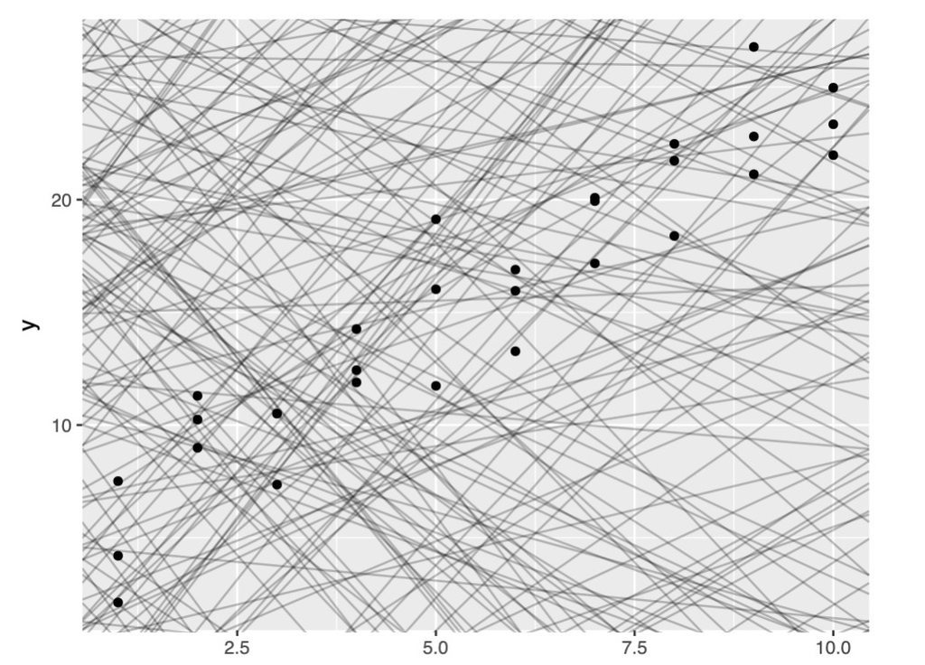

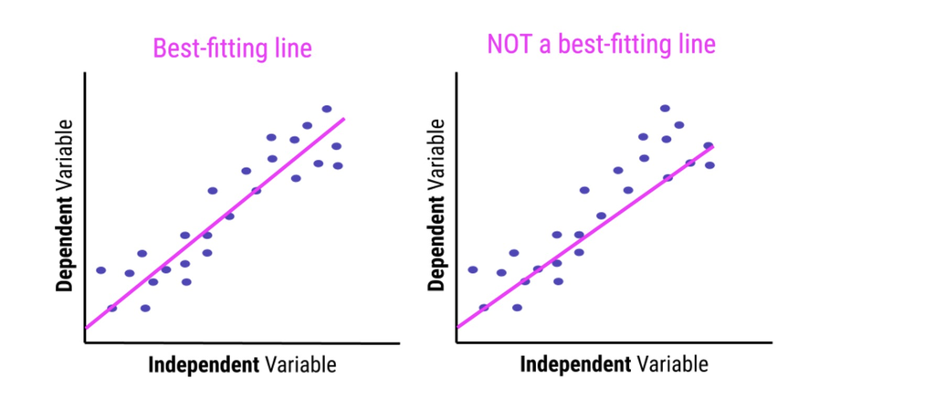

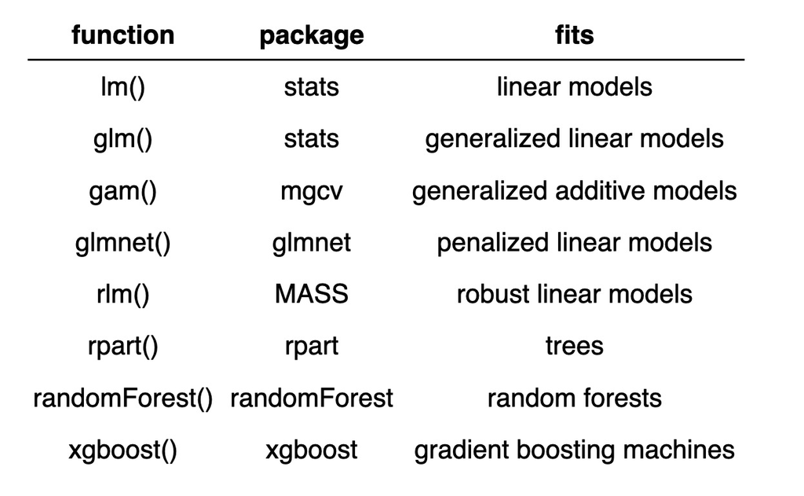

## wages data

We will use the `wages` data posted on moodle. Import it using `read_excel()` in `readxl` package

```r
library(readxl)
wages <- read_excel("./wages.xlsx",na="NA")
```

```r
head(wages)
```

```
## # A tibble: 6 × 8
##   income height weight   age marital  sex    education  afqt
##    <dbl>  <dbl>  <dbl> <dbl> <chr>    <chr>      <dbl> <dbl>
## 1  19000     60    155    53 married  female        13  6.84
## 2  35000     70    156    51 married  female        10 49.4
## 3 105000     65    195    52 married  male          16 99.4
## 4  40000     63    197    54 married  female        14 44.0
## 5  75000     66    190    49 married  male          14 59.7
## 6 102000     68    200    49 divorced female        18 98.8
```

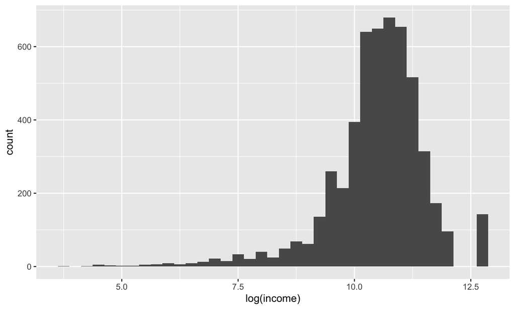

```r
wages %>% ggplot(aes(log(income))) + geom_histogram(binwidth = .25)
```

## Linear Regression

- Better understand the relationship between two variables
  - A dependent variable `y` and an independent variable `x`
- What is the association between these two variables?
  - What is the trend (positive, neutral, negative)?
  - What is the strength of the relationship? (How correlated are the variables)

## Estimation

- Before running linear regression, always good to look at the scatterplot to see if there is a linear relationship between `y` and `x`

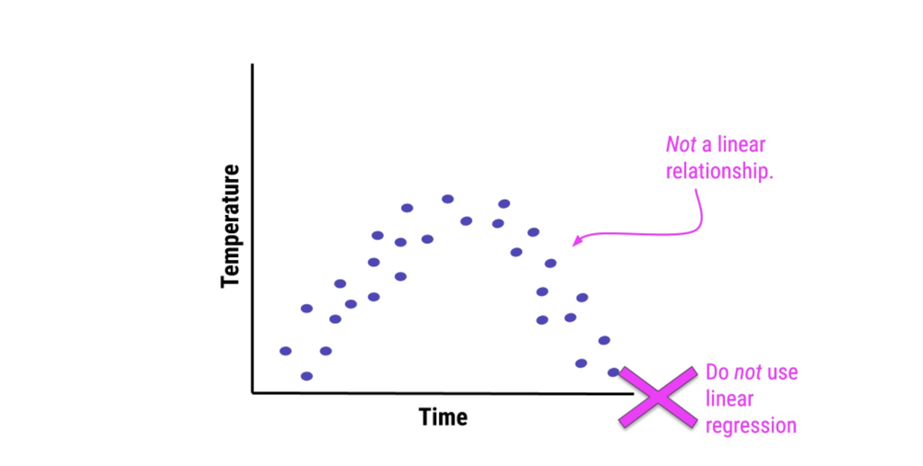

## Ordinary Least Squares

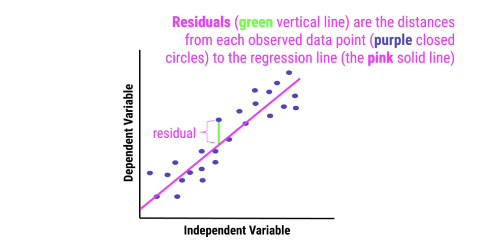

## Residuals

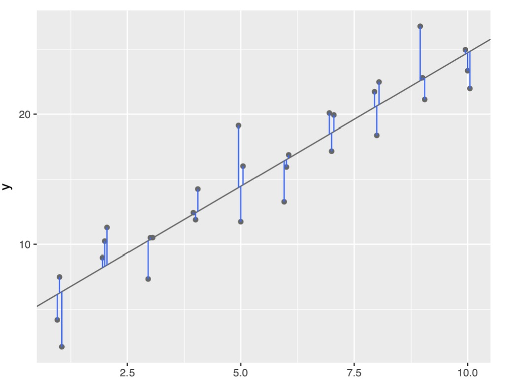

## `lm()`

You can use `lm()` to run a linear regression in R.

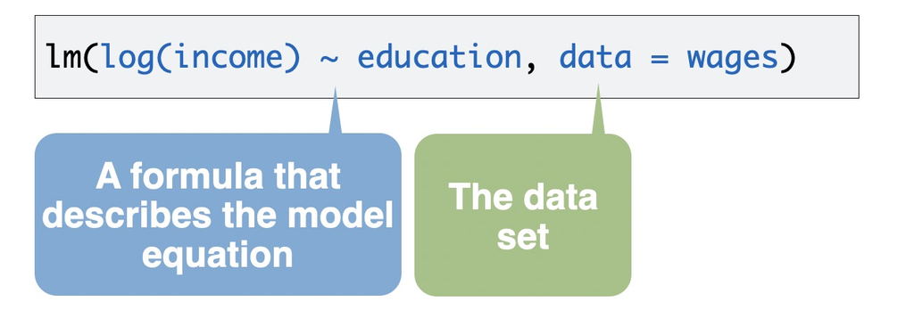

Formula only needs to include the response (variable on the y axis) and predictors (variable on the x-axis)

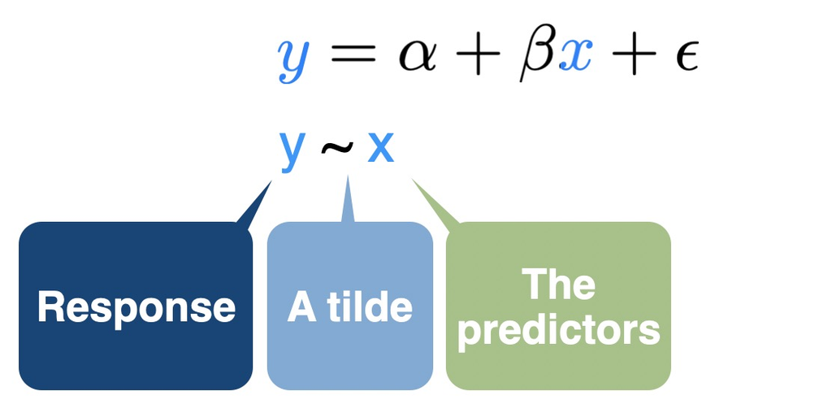

## Output

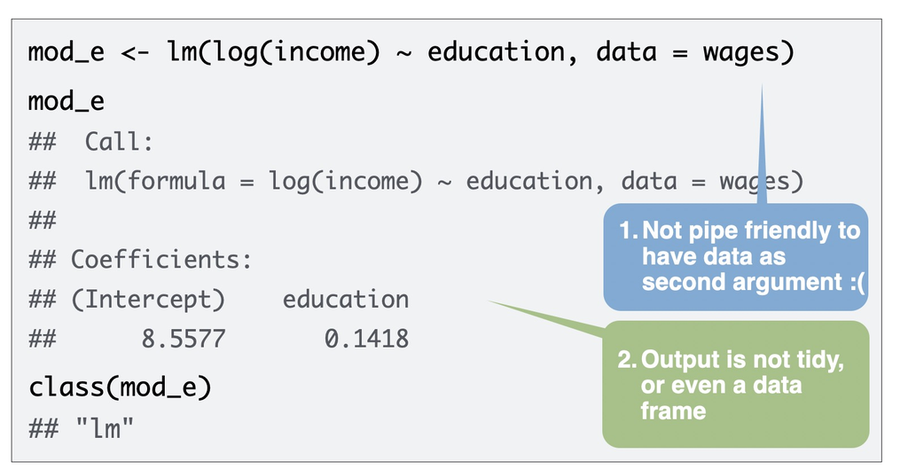

```r
mod_e <- wages %>% lm(log(income)~ education, data=.)
```

## Output

- Slope determines the direction and strength of the relationship between the two variables.
  - It is the change in the number of units of the dependent variable associated with an increase of 1 unit of the independent variable.
  - Slope = 0 \(\rightarrow\) no association
  - Slope > 0 \(\rightarrow\) y increases with increases in x
  - Slope < 0 \(\rightarrow\) y decreases with increases in x

## Model diagnostics

- After fitting a model, it’s necessary to check the model to see if it fits the data well.
- You can use the functions in the `broom` package to assess your model.
- Standard error determines how uncertain the estimates are.
  - Larger standard error \(\rightarrow\) more uncertainty
  - Standard errors characterize how well the best-fitting line models the data.
  - The closer the points are to the line, the lower the standard error will be.

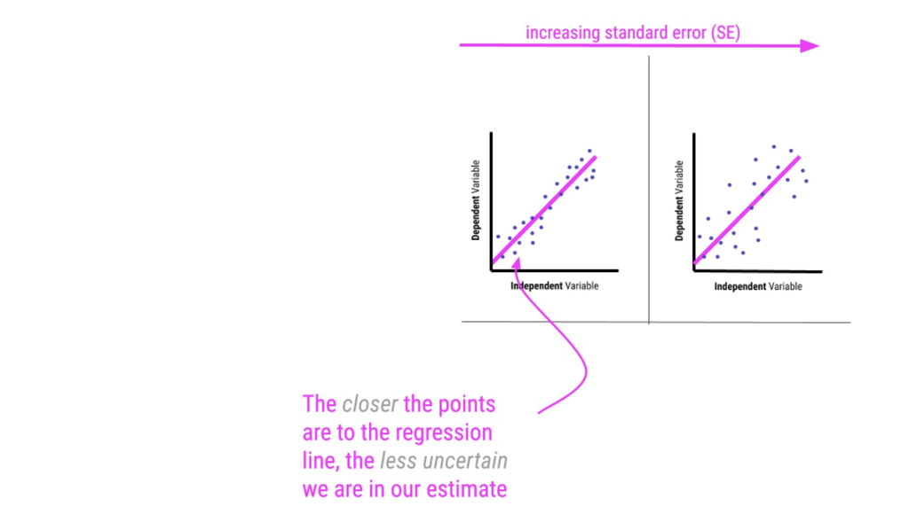

## p-value

- The p-value is a single number that takes into account both the estimate and the uncertainty in that estimate.
- “the probability of getting the observed results (or results more extreme) by chance alone.”
- The lower the p-value, the more significant the association is between two variables.
- Does not tell you as much information as reporting the estimates and standard errors directly.
- If you report a p-value, it’s best to also include the estimate (and standard error)

When carrying out inferential data analysis, you will always want to report an estimate and a measure of uncertainty. For linear regression, this will be the slope estimate and the corresponding standard error.

## `broom` package functions

`tidy()` returns model coefficients standard errors and the p-values for each parameter. It tells you what uncertainty is associated with each parameter in the model (intercept and slope)?

```r
library(broom)
mod_e %>% tidy()
```

```
## # A tibble: 2 × 5
##   term        estimate std.error statistic   p.value
##   <chr>          <dbl>     <dbl>     <dbl>     <dbl>
## 1 (Intercept)    8.56    0.0733      117.  0
## 2 education      0.142   0.00530      26.7 8.41e-148
```

## `glance()`

`glance()` returns model diagnostics. It tells you whether linear model is good for describing the relationship between the two variables.

```r
mod_e %>% glance()
```

```
## # A tibble: 1 × 12
##   r.squared adj.r.s…¹ sigma stati…²   p.value    df logLik    AIC    BIC devia…³
##       <dbl>     <dbl> <dbl>   <dbl>     <dbl> <dbl>  <dbl>  <dbl>  <dbl>   <dbl>
## 1     0.120     0.119 0.992    715. 8.41e-148     1 -7428. 14862. 14881.   5182.
## # … with 2 more variables: df.residual <int>, nobs <int>, and abbreviated
## #   variable names ¹adj.r.squared, ²statistic, ³deviance
```

## `augment()`

`augment()` returns predictions, residuals and other raw values

```r
mod_e %>% augment()
```

```
## # A tibble: 5,264 × 8
##    .rownames `log(income)` education .fitted     .hat .sigma     .cooksd .std.…¹
##    <chr>             <dbl>     <dbl>   <dbl>    <dbl>  <dbl>       <dbl>   <dbl>
##  1 1                  9.85        13   10.4  0.000199  0.992 0.0000305   -0.554
##  2 2                 10.5         10    9.98 0.000554  0.992 0.0000668    0.491
##  3 3                 11.6         16   10.8  0.000359  0.992 0.0000984    0.740
##  4 4                 10.6         14   10.5  0.000195  0.992 0.000000281  0.0536
##  5 5                 11.2         14   10.5  0.000195  0.992 0.0000461    0.687
##  6 6                 11.5         18   11.1  0.000751  0.992 0.0000680    0.425
##  7 7                 11.2         12   10.3  0.000260  0.992 0.000106     0.904
##  8 8                 11.0         12   10.3  0.000260  0.992 0.0000728    0.748
##  9 9                 11.9         13   10.4  0.000199  0.992 0.000233     1.53
## 10 10                11.7         16   10.8  0.000359  0.992 0.000124     0.832
## # … with 5,254 more rows, and abbreviated variable name ¹.std.resid
```

## Correlation is not causation

- The regression only gives the association between the variables.
- Always keep this in mind that never draw causal claims when all you have are associations.

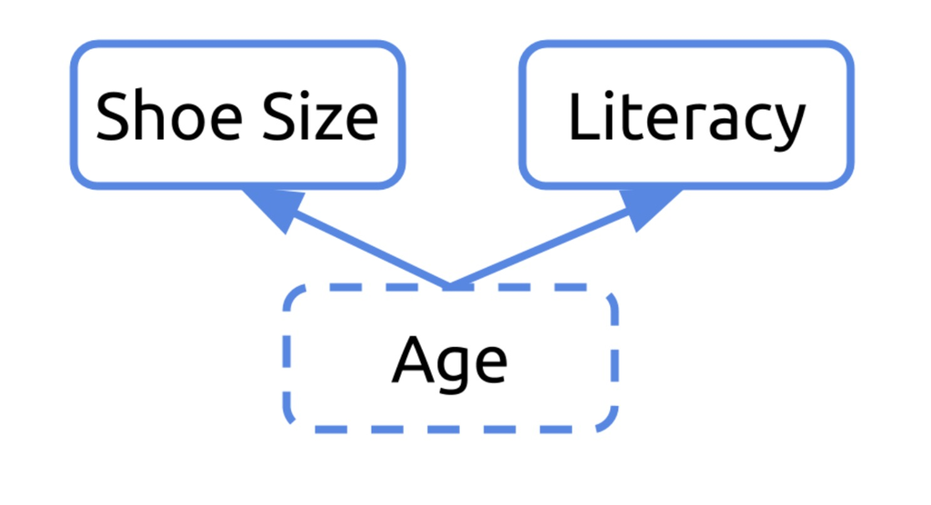

## Multivariate Regression

The multivariate regression is similar to linear regression, except that it accommodates for multiple independent variables. It finds the relationship between the dependent variable and each independent variable, while controlling for all other variables.

```r
mod_eh <- wages %>%
  lm(log(income) ~ education + height, data = .)
mod_eh %>% tidy()
```

[output not shown]

The coefficient is the change in the number of units of the dependent variable associated with an increase of 1 unit of the independent variable, controlling for the other independent variables.

## Your turn

Model log(income) on education, height, and sex. Can you interpret the coefficients?

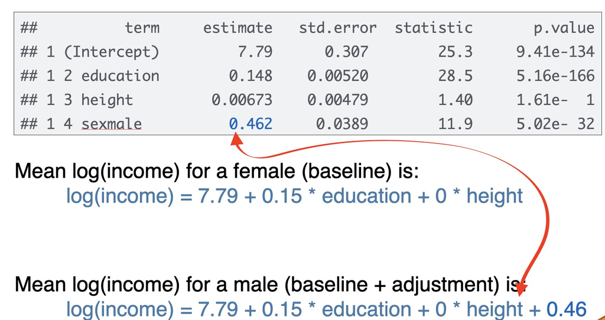

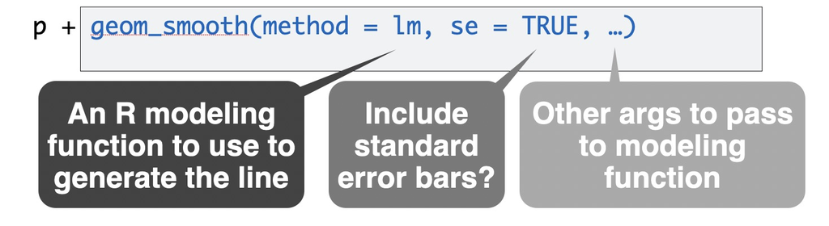

```r
wages %>%
  ggplot(aes(x = height, y = log(income))) +
    geom_point(alpha = 0.1) +
    geom_smooth(method = lm)

wages %>%
  ggplot(aes(x = height, y = log(income))) +
    geom_point(alpha = 0.1) +
    geom_smooth(method = loess)
```

[output not shown]